Resuscitation (2007) **74**, 13—26

[figure not shown]

[figure not shown]

REVIEW

**Drug administration in animal studies of cardiac**

**arrest does not reﬂect human clinical experience**<sup>�</sup>

**Joshua C. Reynolds** <sup>**a**</sup>**, Jon C. Rittenberger** <sup>**b**</sup><sup>**,**</sup><sup>**∗**</sup>**, James J. Menegazzi** <sup>**b**</sup>

a *School of Medicine, University of Pittsburgh, Pittsburgh, PA, United States*

b *Department of Emergency Medicine, University of Pittsburgh, Pittsburgh, PA, United States*

Received 4 August 2006; received in revised form 28 September 2006; accepted 2 October 2006

**KEYWORDS**

Cardiopulmonary

resuscitation (CPR);

Cardiac arrest;

Resuscitation;

Drug therapy

**Summary**

*Introduction:* To date, there is no evidence showing a beneﬁt from any advanced

cardiac life support (ACLS) medication in out-of-hospital cardiac arrest (OOHCA),

despite animal data to the contrary. One explanation may be a difference in the time

to ﬁrst drug administration. Our previous work has shown the mean time to ﬁrst drug

administration in clinical trials is 19.4 min. We hypothesized that the average time

to drug administration in large animal experiments occurs earlier than in OOHCA

clinical trials.

*Methods:* We conducted a literature review between 1990 and 2006 in MEDLINE

using the following MeSH headings: swine, dogs, resuscitation, heart arrest, EMS,

EMT, ambulance, ventricular ﬁbrillation, drug therapy, epinephrine, vasopressin,

amiodarone, lidocaine, magnesium, and sodium bicarbonate. We reviewed the

we identiﬁed 119 papers that contained unique information on time to medication

administration. The data are reported as mean, ranges, and 95% conﬁdence inter-

vals. Mean time to ﬁrst drug administration in animal laboratory studies and clinical

trials was compared with a *t*-test. Regression analysis was performed to determine

if time to drug predicted ROSC.

*Results:* Mean time to ﬁrst drug administration in 2378 animals was 9.5 min (range

3.0—28.0; 95% CI around mean 2.78, 16.22). This is less than the time reported in

clinical trials (19.4 min, *p* < 0.001). Time to drug predicted ROSC (odds ratio 0.844;

95% CI 0.738, 0.966).

*Conclusion:* Shorter drug delivery time in animal models of cardiac arrest may be

one reason for the failure of animal studies to translate successfully into the clinical

arena.

© 2006 Elsevier Ireland Ltd. All rights reserved.

� A Spanish translated version of the summary of this article appears as Appendix in the ﬁnal online version at

10.1016/j.resuscitation.2006.10.032.

∗ Corresponding author at: Department of Emergency Medicine, University of Pittsburgh, 230 McKee Place, Suite 400, Pittsburgh,

PA 15213, United States. Tel.: +1 412 647 9489; fax: +1 412 647 6999.

*E-mail address:* rittenbergerjc@upmc.edu (J.C. Rittenberger).

0300-9572/$ — see front matter © 2006 Elsevier Ireland Ltd. All rights reserved.

doi:10.1016/j.resuscitation.2006.10.032

14

J.C. Reynolds et al.

**Contents**

Introduction..................................................................................................

14

Methods......................................................................................................

14

Results.......................................................................................................

19

Discussion....................................................................................................

20

Conclusions ..................................................................................................

20

Conﬂict of interest statement................................................................................

20

Acknowledgements...........................................................................................

21

Appendix A...................................................................................................

21

References...................................................................................................

22

**Introduction**

Despite numerous clinical trials, survival rates in

out-of-hospital cardiac arrest (OOHCA) remain low.

To date, there is no evidence that supports the use

of ACLS drugs in this setting.<sup>1—3</sup>Animal studies, in

contrast, have demonstrated superior survival rates

with drug use.<sup>4—13</sup>One reason for failure of ani-

mal studies to translate to clinical practice may be

the time at which the ﬁrst drug is delivered. Pre-

vious work has demonstrated the average time to

ﬁrst drug administration in clinical trials is 19.4 min

are given during the late metabolic phase of car-

diac arrest. Consequently, it is not surprising they

are ineffective. Based on our laboratory and clinical

experience, we hypothesized that the average time

to drug administration in large animal experiments

occurs earlier than in OOHCA clinical trials.

**Methods**

We conducted a comprehensive literature review

between 1990 and 2006 in MEDLINE using the fol-

lowing MeSH headings: swine, dogs, resuscitation,

heart arrest, EMS, EMT, ambulance, ventricular ﬁb-

rillation, drug therapy, epinephrine, vasopressin,

amiodarone, lidocaine, magnesium, and sodium

bicarbonate. We used no language restriction.

We used OVID to search MEDLINE and obtain

the abstracts. All abstracts were printed and

two reviewers (JCR and JCR) jointly reviewed all

abstracts. We eliminated the following from further

review: small animal; non-peer reviewed; all with-

out primary animal data (editorials, case reports,

review articles, letters, practice guidelines); stud-

ies modeling trauma, sepsis, or burns; studies

performed in vitro; those studies were no exoge-

nous medications were given. We then reviewed

independently the full manuscripts of all remaining

papers for data describing the time to ﬁrst medica-

tion administration. Both reviewers then compared

the articles captured.

The type of animal, number of animals, time

to ﬁrst drug administration, route of medication

administration, type of medication, method of

delivery (bolus versus infusion), return of sponta-

neous circulation (ROSC) and short-term survival

were abstracted from the articles. Unlike most

meta-analyses where we compare the effect size

as a function of treatment compared to control

across the studies, our analysis compares the mean

response time to the ‘minimally acceptable’ time.

Consequently, our effect size is the sample mean

and our goal is to combine the study results, derive

a conﬁdence interval for mean response time and

compare that range to what the guidelines deﬁne as

appropriate. Given that variances were not avail-

able for all studies, we used the weighted study

sample sizes relative to the entire sample size

across the 119 studies to estimate the effect size

variance<sup>15</sup>: weight*i* = *N**i*, where *N**i* is the sample size

for each study and <sup>�</sup><sup>k</sup>

i=1<sup>weight</sup><sup>i</sup> <sup>=</sup><sup>N</sup><sup>which is the</sup>

total sample size across all the studies.

Due to the large differences in sample sizes

across the studies (and obvious heterogeneity),

we chose to analyze the results using the ran-

dom effects model as recommended by Hunter and

method to estimate the conﬁdence interval around

the mean. We used Microsoft Excel XP 2002 (Red-

mond, WA) and STATA 9.0 (College Station, TX) to

record and analyze the data. We report the mean

times, ranges, and the respective 95% conﬁdence

intervals around the mean. We next compared the

data from this review with that of our previous

study in clinical trials to determine if time to drug

predicted ROSC. A *t*-test was completed to deter-

mine if the mean time to drug administration was

different between the clinical trial data and the

animal trial data. Multivariate logistic regression

was used to determine predictors of ROSC in the

Drug administration in animal

15

**Table 1**

Time to drug administration (min) by study

Study

Number of

subjects

Time to drug

administration

First medication received

Krieter et al.<sup>27</sup>

10

8

Epinephrine

Loeckinger et al.<sup>28</sup>

8

7

Vasopressin

10

7

Epinephrine

Krismer et al.<sup>29</sup>

7

7

Vasopressin

6

7

Epinephrine

Little et al.<sup>30</sup>

13

13

Angiotensin II

11

13

Epinephrine

13

13

Angiotensin II + epinephrine

Johansson et al.<sup>31</sup>

24

7

Epinephrine

Bahlmann et al.<sup>32</sup>

14

18

Vasopressin

Behringer et al.<sup>33</sup>

11

9

Epinephrine

Voelckel et al.<sup>34</sup>

12

16

Vasopressin

6

16

Vasopressin + epinephrine

Holzer M et al.<sup>35</sup>

19

10

Endothelin-1

6

10

Epinephrine

Johansson et al.<sup>36</sup>

12

7

Vasopressin

12

7

Epinephrine

Prengel et al.<sup>7</sup>

7

7

Epinephrine

7

7

Vasopressin

7

7

Vasopressin + epinephrine

Amann et al.<sup>37</sup>

16

7

Vasopressin

9

7

Epinephrine

11

7

Novel vasopressor

12

4

Epinephrine

11

4

Vasopressin

2

10

Vasopressin

3

10

Epinephrine

Adams et al.<sup>38</sup>

12

18

Vasopressin

Schwarz et al.<sup>39</sup>

7

18

Vasopressin

7

28

Amiodarone

Vukmir et al.<sup>40</sup>

12

5

Epinephrine

20

15

Epinephrine

Manning et al.<sup>41</sup>

5

10.5

Epinephrine

5

10.5

Aortic occlusion + epinephrine

5

10.5

Aortic occlusion + intraaortic epinephrine

Strohmenger et al.<sup>42</sup>

7

7

Epinephrine

7

7

Vasopressin

Ayoub et al.<sup>43</sup>

8

10

Cariporide

8

10

Epinephrine

8

10

Cariporide + epinephrine

Stadlbauer et al.<sup>44</sup>

6

7

Epinephrine

6

7

Epinephrine + vasopressin

Mayr et al.<sup>45</sup>

6

12

Epinephrine

6

12

Vasopressin

6

12

High-dose epinephrine + vasopressin

6

12

Standard-dose epinephrine + vasopressin

Amann et al.<sup>46</sup>

11

7

Vasopressin

5

7

Epinephrine

5

12

Vasopressin

4

12

Epinephrine

Hilwig et al.<sup>47</sup>

12

8

Standard-dose epinephrine

12

8

Standard-dose epinephrine + � blocker

10

8

High-dose epinephrine + � blocker

10

8

Phenylephrine + � blocker

Nozari et al.<sup>48</sup>

11

7

Aortic occlusion + epinephrine

12

7

Epinephrine IV

16

J.C. Reynolds et al.

**Table 1 (***Continued* **)**

Study

Number of

subjects

Time to drug

administration

First medication received

Seaberg et al.<sup>9</sup>

7

9

Combination therapy including

epinephrine + novel

cardiocerebral-protective agent

9

9

Magnesium

8

10

Epinephrine

Menegazzi et al.<sup>13</sup>

9

9

Standard-dose epinephrine

9

12

Standard-dose epinephrine

9

15

Standard-dose epinephrine

9

12

Standard-dose epinephrine

7

15

Standard-dose epinephrine

9

8

High-dose epinephrine

8

11

High-dose epinephrine

Prengel et al.<sup>49</sup>

8

5

Epinephrine

8

5

Vasopressin

Wenzel et al.<sup>50</sup>

8

18

Vasopressin

8

18

Vasopressin + epinephrine

Wenzel et al.<sup>51</sup>

7

7

Vasopressin

7

7

Vasopressin + nitroglycerin

Lurie et al.<sup>52</sup>

12

8

Epinephrine + vasopressin

12

8

Epinephrine

Berg et al.<sup>53</sup>

12

11

Epinephrine

Holzer et al.<sup>54</sup>

21

10

Endothelin-1

6

10

Epinephrine

Prengel et al.<sup>55</sup>

6

6

Epinephrine

Bleske et al.<sup>56</sup>

7

5

Intra-nasal epinephrine

6

5

Epinephrine IV

Tang et al.<sup>57</sup>

10

9

Epinephrine

Lindner et al.<sup>58</sup>

14

5.5

High-dose epinephrine

Lindner et al.<sup>59</sup>

7

7

Epinephrine

21

7

Vasopressin

Idris et al.<sup>60</sup>

24

17

Epinephrine

Bar-Joseph et al.<sup>61</sup>

36

17

Epinephrine

Paradis et al.<sup>62</sup>

13

8

Epinephrine

Bleske et al.<sup>63</sup>

26

6

Epinephrine

Lindner et al.<sup>64</sup>

28

8

Epinephrine

Wolf et al.<sup>65</sup>

7

7

Epinephrine

7

7

Norepinephrine

7

7

Vasopressin

Blecic et al.<sup>66</sup>

6

9

Atropine

6

9

Atropine

Prengel et al.<sup>67</sup>

8

5

Epinephrine

8

5

Vasopressin

Berg et al.<sup>68</sup>

15

11

Standard-dose epinephrine

15

11

High-dose epinephrine

Strohmenger et al.<sup>69</sup>

21

7

Vasopressin

Bleske et al.<sup>70</sup>

9

12

Bicarbonate

9

13

Epinephrine

Menegazzi et al.<sup>5</sup>

9

8

Epinephrine

9

9

Epinephrine

Manning et al.<sup>71</sup>

16

12

Epinephrine

Wenzel et al.<sup>72</sup>

9

18

Epinephrine

9

18

Vasopressin

Mayr et al.<sup>73</sup>

7

3

Epinephrine

7

3

Vasopressin

7

3

Epinephrine + vasopressin

Drug administration in animal

17

**Table 1 (***Continued* **)**

Study

Number of

subjects

Time to drug

administration

First medication received

Gervais et al.<sup>74</sup>

7

8

Epinephrine

7

8

Phenylephrine

7

8

Epinephrine + � blocker

Nejman et al.<sup>75</sup>

6

13

Novel vasopressor

Achleitner et al.<sup>76</sup>

5

7

Vasopressin

5

7

Epinephrine

5

12

Vasopressin

6

12

Epinephrine

Neimann et al.<sup>6</sup>

14

8

Epinephrine

14

7.5

Epinephrine

Voelckel et al.<sup>77</sup>

12

7

Vasopressin

Lindner et al.<sup>78</sup>

7

7

Epinephrine

7

7

Vasopressin

Gazmuri et al.<sup>79</sup>

8

8

Bicarbonate

8

8

Carbicarb

Bleske et al.<sup>80</sup>

7

6

Intra-nasal epinephrine

Jameson et al.<sup>81</sup>

19

18

Epinephrine

Wenzel et al.<sup>82</sup>

7

7

Vasopressin IV

9

7

Endobronchial vasopressin

Lindner et al.<sup>83</sup>

7

5

Epinephrine

7

5

Norepinephrine

Angelos et al.<sup>84</sup>

8

15

Standard-dose epinephrine

8

15

High-dose epinephrine

Prengel et al.<sup>85</sup>

7

7

Vasopressin

7

7

Epinephrine

Littmann et al.<sup>86</sup>

20

6.5

Epinephrine

20

6

Epinephrine

DeBehnke et al.<sup>87</sup>

8

15

High-dose epinephrine

8

15

Standard-dose epinephrine

Manning et al.<sup>88</sup>

8

10

Epinephrine

Schleien et al.<sup>89</sup>

16

8

Epinephrine

Strohmenger et al.<sup>90</sup>

21

7

Epinephrine

Lindberg et al.<sup>91</sup>

6

6

Epinephrine

6

6

Norepinephrine

Wenzel et al.<sup>92</sup>

6

7

Vasopressin

6

7

Epinephrine

Menegazzi et al.<sup>6</sup>

8

9

Combination therapy including

epinephrine + novel

cardiocerebral-protective agent

8

9

Epinephrine

8

9

Lidocaine + bretylium

8

9

Propanolol

8

9

Novel cardiocerebral-protective agent

8

10

Epinephrine

Suddath et al.<sup>93</sup>

10

10

Epinephrine

Nozari et al.<sup>94</sup>

11

13

Epinephrine

11

13

Vasopressin

Krismer et al.<sup>95</sup>

14

4

Epinephrine

14

4

Vasopressin

Idris et al.<sup>96</sup>

24

17

Epinephrine

Barton et al.<sup>97</sup>

4

12

Aortic occlusion + epinephrine

4

12

Epinephrine

Berg et al.<sup>98</sup>

15

16

High-dose epinephrine

15

16

Standard-dose epinephrine

Killingsworth et al.<sup>99</sup>

8

9

� Blocker

Cairns et al.<sup>100</sup>

14

8

Epinephrine

18

J.C. Reynolds et al.

**Table 1 (***Continued* **)**

Study

Number of

subjects

Time to drug

administration

First medication received

Rubertsson et al.<sup>101</sup>

8

11

Aortic occlusion + epinephrine

8

11

Epinephrine IV

Wenzel et al.<sup>102</sup>

6

7

Vasopressin IV

6

7

Intraosseous vasopressin

Jasani et al.<sup>103</sup>

36

9

Epinephrine

Rubertsson et al.<sup>104</sup>

22

9

Epinephrine

Wenzel et al.<sup>105</sup>

12

7

Epinephrine

Wenzel et al.<sup>106</sup>

8

18

Vasopressin

Voelckel et al.<sup>107</sup>

6

7

Vasopressin

6

7

Epinephrine

Hoekstra et al.<sup>108</sup>

7

13

Norepinephrine

7

13

Epinephrine

Leong et al.<sup>109</sup>

11

11

Epinephrine

12

10

Epinephrine

Kornberger et al.<sup>110</sup>

6

7

Epinephrine

Schwarz et al.<sup>111</sup>

8

18

Vasopressin

Krismer et al.<sup>112</sup>

6

9

Epinephrine

6

9

Epinephrine + novel K<sup>+</sup>channel blocker

Nozari et al.<sup>113</sup>

10

7

Aortic occlusion + vasopressin

10

7

Vasopressin

Voelckel et al.<sup>114</sup>

6

16

Epinephrine

6

16

Vasopressin

6

16

Vasopressin + epinephrine

Roberts et al.<sup>115</sup>

6

3

Novel �1-agonist

6

3

Standard-dose epinephrine

6

3

High-dose epinephrine

Prengel et al.<sup>87</sup>

7

7

Epinephrine

7

7

Vasopressin

Brunette et al.<sup>116</sup>

10

15

Standard-dose epinephrine

10

15

High-dose epinephrine

Klouche et al.<sup>117</sup>

7

9

Novel �2-agonist

7

9

Epinephrine

Hornchen et al.<sup>118</sup>

8

3

Standard-dose epinephrine

8

3

High-dose epinephrine

Wenzel et al.<sup>119</sup>

6

7

Epinephrine

6

7

Vasopressin

6

12

Epinephrine

6

12

Vasopressin

Bar-Joseph et al.<sup>120</sup>

38

17

Epinephrine

Hoekstra et al.<sup>121</sup>

10

13

Epinephrine

Angelos et al.<sup>122</sup>

8

10

Epinephrine

Hilwig et al.<sup>123</sup>

10

8

Endothelin-1 + epinephrine

17

8

Epinephrine

DeBehnke et al.<sup>124</sup>

5

13

Endothelin-1

6

13

Epinephrine

Kornberger et al.<sup>125</sup>

7

7

Epinephrine

7

7

Vasopressin

Mulligan et al.<sup>126</sup>

11

8

Epinephrine

7

8

Vasopressin

11

8

Epinephrine + vasopressin

Gedeborg et al.<sup>127</sup>

13

10

Aortic occlusion + epinephrine

13

10

Epinephrine

Babar et al.<sup>128</sup>

17

8

Epinephrine

18

8

Vasopressin

Hornchen et al.<sup>129</sup>

8

3

Epinephrine

8

3

Endobronchial epinephrine

Drug administration in animal

19

**Table 1 (***Continued* **)**

Study

Number of

subjects

Time to drug

administration

First medication received

Lindner et al.<sup>130</sup>

7

7

Angiotensin II

Kern et al.<sup>131</sup>

16

12.5

Epinephrine

16

12.5

Vasopressin

16

12.5

Vasopressin

Hornchen et al.<sup>132</sup>

8

3

Epinephrine IV

8

3

Endobronchial epinephrine

Schindler et al.<sup>133</sup>

26

10

Epinephrine

Hornchen et al.<sup>134</sup>

16

3

Epinephrine

Hornchen et al.<sup>135</sup>

10

3

Norepinephrine IV

10

3

Endotracheal norepinephrine

Hornchen et al.<sup>136</sup>

26

3

Epinephrine IV

18

3

Endotracheal epinephrine

Liu et al.<sup>137</sup>

10

10

Aortic occlusion + vasopressin

10

10

Aortic occlusion + epinephrine

10

10

Epinephrine

Manning et al.<sup>138</sup>

12

12

Epinephrine

Subject group given for studies comparing interventions.

animal studies. Predictor variables included: time

to drug, route of delivery (IV or ET), induction of

hypothermia, and type of drug. Time to drug was

analyzed as a continuous variable in this regres-

sion model. The Hosmer—Lemeshow test was used

to assess goodness of ﬁt.

**Results**

Our literature review yielded 332 abstracts. Of

these, 197 were selected for review of the full

manuscript. The reason for exclusion is presented

in Figure 1. Of the 197 manuscripts, 119 contained

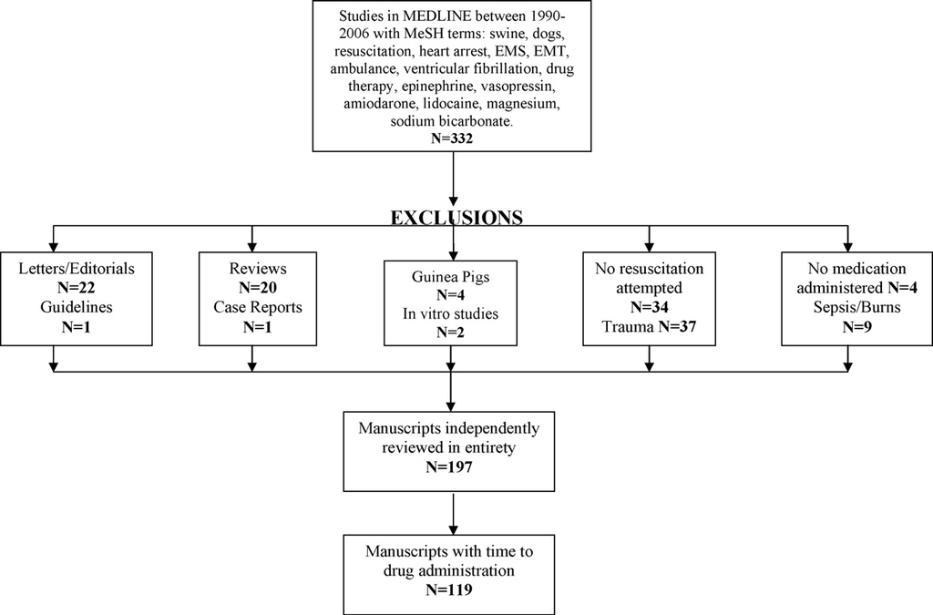

**Figure 1**

Results of decision algorithm used.

20

J.C. Reynolds et al.

unique data on time to ﬁrst drug administration.

There was 100% agreement between both reviewers

on which studies to include in our analysis (Table 1).

The average time to ﬁrst medication administration

in these 2378 animals was 9.5 min (range 3.0—28.0;

95% CI around mean 2.78, 16.22). This was less than

our previously reported clinical trial data (19.4 min;

*p* < 0.001). In the regression analysis, time to drug

was the lone predictor of ROSC (odds ratio 0.844;

95% CI 0.738, 0.966). This regression model had

acceptable ﬁt (Hosmer—Lemeshow value 0.195).

**Discussion**

Drugs are administered approximately 10 min ear-

lier in animal studies than in clinical trials.

Speciﬁcally, animal studies give drugs during the

circulatory phase while clinical trials give drugs dur-

ing the metabolic phase. This delay may be one

reason animal studies have failed to translate to

clinical practice.

Weisfeldt and Becker have proposed a three-

phase model of cardiac arrest.<sup>17</sup>The ﬁrst phase

is electrical and lasts from 0 to 4 min. During

this initial phase, ventricular ﬁbrillation responds

well to countershock. The second phase, from

4 to 10 min, is the circulatory phase. Both ani-

mal and human data support the initiation of CPR

before attempting deﬁbrillation to ensure ade-

quate tissue oxygenation and perfusion. Data in this

phase also supports supplementary administration

of vasopressors with CPR. Immediate rescue shock

alone has been ineffective during this phase.<sup>13,18,19</sup>

The third phase of cardiac arrest occurs beyond

10 min. Little research has been conducted in this

metabolic phase, even though it is usually during

this phase that advanced life support is initiated

and patients receive their ﬁrst dose of medica-

tion. One study has suggested that cardiopulmonary

bypass may be effective and result in neurologi-

cally intact survivors.<sup>20</sup>Using a swine model, we

demonstrated recently that these phases may be

extended through the use of an optimal resuscita-

tion incorporating CPR and a drug cocktail prior to

rescue countershock.<sup>21</sup>This model would predict a

21% probability of ROSC with drug administration at

19.4 min, and an 83% probability of ROSC with drug

administration at 9.5 min.

The 2005 ILCOR guidelines downplay the import

of medication administration.<sup>22</sup>In light of this lit-

erature review and our own experience with animal

models, we believe that these drugs are not inert,

but only effective when administered during the

circulatory phase of cardiac arrest. These data sug-

gest a shift in resuscitation care to improve drug

delivery in the out-of-hospital setting. One method

employed to decrease time to drug is system-wide

changes in dispatch protocols. These changes have

been shown to decrease time to medication admin-

istration by 3.5 min.<sup>23</sup>A second method to improve

drug delivery time is to provide ﬁrst responders

with the ability to establish intraosseus access and

give drugs. We have demonstrated previously that

the use of an intraosseus needle by prehospital

basic life support providers is feasible and compares

favorably with prior studies of advanced life sup-

port intravenous catheter placement.<sup>24,25</sup>If drug

delivery continues to occur late during resusci-

tative efforts, we are unlikely to ﬁnd a beneﬁt

from any drug or cocktail of drugs in the clinical

setting.

Our study has several limitations. First, it is

limited to a retrospective review of the litera-

ture. There is the possibility that studies have

been missed, but we believe this to have been

minimized by our inclusive search criteria and

extensive review. Second, the animals used are

young, healthy animals. The cardiovascular phys-

iology of these animals may be different than that

of many people who experience OOHCA. Third,

time to drug delivery is reliably and consistently

recorded in animal studies. However, in clinical set-

tings this data is limited due to being self-reported.

The time from collapse to EMS activation is rarely

known. Finally, the outcomes assessed are ROSC

and short-term survival. Most animal studies do not

provide information on neurologically intact sur-

vival, which is the most relevant outcome from the

perspective of the patient. We note that previous

studies showing short-term beneﬁts have failed to

translate to long-term survival.<sup>26</sup>

**Conclusions**

Time to ﬁrst drug delivery in animal resuscitation

studies occurs approximately 10 min earlier than in

clinical trials. In animal trials, time to drug predicts

ROSC. These data suggest that one reason for the

failure of animal studies to translate into clinical

practice may be delay to drug delivery. We suggest

that an emphasis on gaining vascular access may

improve drug effectiveness.

**Conﬂict of interest statement**

None of the authors have a conﬂict of interest to

report.

Drug administration in animal

21

**Acknowledgements**

Dr. Rittenberger and Dr. Menegazzi are supported

by the Clinical Research Skills Development Core

of the Resuscitation Outcomes Consortium through

the National Heart, Lung and Blood Institute 5U01

HL077871-02. Dr. Menegazzi is also supported by

the National Heart, Lung and Blood Institute 5R01

HL080483-2.

**Appendix A**

Time to medication administration (min) in clinical

studies of cardiac arrest. Subject group given for

studies comparing interventions. Grey shading indi-

cates studies speciﬁcally evaluating time to study

drug administration.

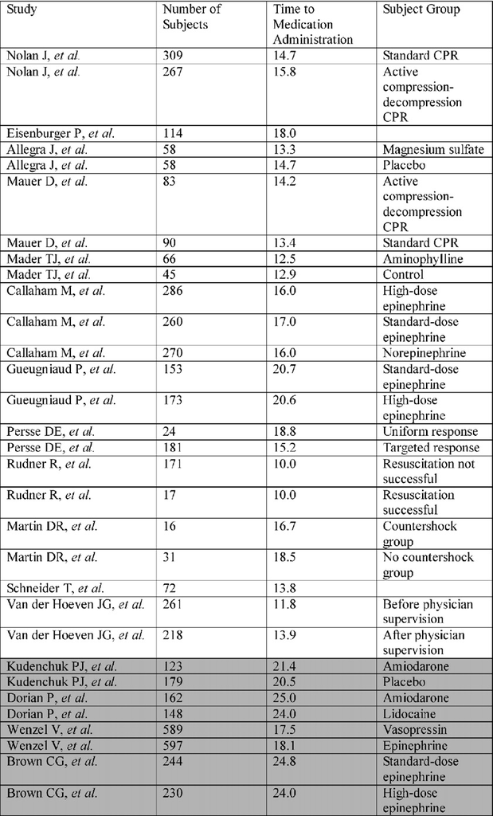

22

J.C. Reynolds et al.

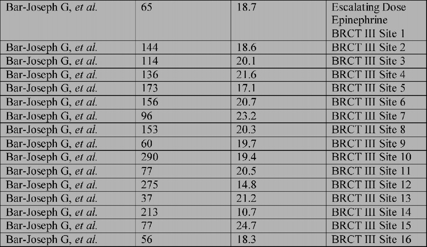

**References**

1. Stiell IG, Wells GA, Field B, et al. Advanced cardiac life

support in out-of-hospital cardiac arrest. N Engl J Med

2004;351:647—56.

2. Fatovich DM, Prentice DA, Dobb GJ. Magnesium in cardiac

arrest (the magic trial). Resuscitation 1997;35:237—41.

3. Wang HE, Min A, Hostler D, Chang CH, Callaway CW. Differ-

ential effects of out-of-hospital interventions on short- and

long-term survival after cardiopulmonary arrest. Resuscita-

tion 2005;67:69—74.

4. Niemann JT, Cairns CB, Sharma J, Lewis RJ. Treatment of

prolonged ventricular ﬁbrillation. Immediate countershock

versus high-dose epinephrine and CPR preceding counter-

shock. Circulation 1992;85:281—7.

5. Menegazzi JJ, Davis EA, Yealy DM, et al. An experimental

algorithm versus standard advanced cardiac life support in

a swine model of out-of-hospital cardiac arrest. Ann Emerg

Med 1993;22:235—9.

6. Menegazzi JJ, Seaberg DC, Yealy DM, Davis EA, MacLeod BA.

Combination pharmacotherapy with delayed countershock

vs. standard advanced cardiac life support after pro-

longed ventricular ﬁbrillation. Prehosp Emerg Care 2000;4:

31—47.

7. Prengel AW, Linstedt U, Zenz M, Wenzel V. Effects of

combined administration of vasopressin, epinephrine, and

norepinephrine during cardiopulmonary resuscitation in

pigs. Crit Care Med 2005;33:2587—91.

8. Cammarata G, Weil MH, Sun S, Tang W, Wang J, Huang L. B1-

adrenergic blockade during cardiopulmonary resuscitation

improves survival. Crit Care Med 2004;32:S440—3.

9. Seaberg DC, Menegazzi JJ, Check B, MacLeod BA, Yealy DM.

Use of a cardiocerebral-protective drug cocktail prior to

countershock in a porcine model of prolonged ventricular

ﬁbrillation. Resuscitation 2001;51:301—8.

10. Prengel AW, Linder KH, Wenzel V, Tugtekin I, Anhaupl T.

Splanchnic and renal blood ﬂow after cardiopulmonary

resuscitation with epinephrine and vasopressin in pigs.

Resuscitation 1998;38:19—24.

11. Wenzel

V,

Lindner

KH,

Augenstein

S,

Prengel

A,

Strohmenger HU. Vasopressin combined with epinephrine

decreases cerebral perfusion compared with vasopressin

alone during cardiopulmonary resuscitation in pigs. Stroke

1998;29:1462—8.

12. Mulligan KA, McKnite SH, Lindner KH, Lindstrom PJ, Det-

loff B, Lurie KG. Synergistic effects of a vasopressin plus

epinephrine during cardiopulmonary resuscitation. Resus-

citation 1997;35:265—71.

13. Menegazzi JJ, Wang HE, Lightfoot CB, et al. Immedi-

ate deﬁbrillation versus interventions ﬁrst in a swine

model of prolonged ventricular ﬁbrillation. Resuscitation

2003;59:261—70.

14. Rittenberger JC, Bost JM, Menegazzi JJ. Time to give the

ﬁrst medication during resuscitation in out-of-hospital car-

diac arrest. Resuscitation 2006;70:201—6.

15. Pititti DB. Meta Analysis, Decision Analysis, and Cost-

Effectiveness Analysis. Oxford University Press; 1994.

16. Hunter JE, Schmidt FL. Methods of Meta-Analysis: Correct-

ing Error and Bias in Research Findings. Newbury Park, CA:

Sage; 1990. pp. 110—112.

17. Weisfeldt ML, Becker LB. Resuscitation after cardiac arrest.

JAMA 2002;288:3035—8.

18. Menegazzi JJ, Callaway CW, Sherman LD, et al. Ven-

tricular ﬁbrillation scaling exponent can guide timing of

deﬁbrillation and other therapies. Circulation 2004;109:

926—31.

19. Wang HE, Menegazzi JJ, Lightfoot CB, et al. Effects of

biphasic vs. monophasic deﬁbrillation on the scaling expo-

nent in a swine model of prolonged ventricular ﬁbrillation.

Acad Emerg Med 2001;8:771—80.

20. Beyersdorf F, Kirsch M, Buckberg GG, Allen BS. Warm

glutamate/aspartate-enriched blood cardioplegic solution

for perioperative sudden death. J Thorac Cardiovasc Surg

1992;104:1141—7.

21. Rittenberger JC, Menegazzi JJ, Callaway CW. Association of

delay to ﬁrst intervention with return of spontaneous cir-

culation in a swine model of cardiac arrest. Resuscitation,

in press.

22. International Liaison Committee on Resuscitation. Part 4.

Advanced life support. Resuscitation 2005;67:213—47.

23. Persse DE, Key CB, Bradley RN, Miller CC, Dhingra A. Car-

diac arrest survival as a function of ambulance deployment

strategy in a large urban emergency medical services sys-

tem. Resuscitation 2003;59:97—104.

24. Guyette FX, Rittenberger JC, Platt TE, Suffoletto BS,

Hostler DP, Wang HE. Feasibility of basic emergency medi-

cal technicians to perform selected advanced life support

interventions. Prehosp Emerg Care 2006;10(4):518—21.

Drug administration in animal

23

25. Miller DD, Guimond G, Hostler DP, Platt T, Wang HE. Feasi-

bility of sternal intraosseus access by emergency medical

technician students. Prehosp Emerg Care 2005;9(1):73—8.

26. Callaham M, Madsen CD, Barton CW, Saunders CE, Pointer

J. A randomized clinical trial of high-dose epinephrine and

norepinephrine vs. standard-dose epinephrine in prehospi-

tal cardiac arrest. JAMA 1992;268(19):2667—72.

27. Krieter H, Denz C, Janke C, et al. Hypertonic-hyperonocotic

solutions reduce the release of cardiac troponin I and S-

100 after successful cardiopulmonary resuscitation in pigs.

Anesth Analg 2002;95:1031—6.

28. Loeckinger A, Kleinsasser A, Wenzel V, et al. Pulmonary

gas exchange after cardiopulmonary resuscitation with

either vasopressin or epinephrine. Crit Care Med 2002;30:

2059—62.

29. Krismer AC, Wenzel V, Voelckel WG, et al. Effects of

vasopressin on adrenal gland regional perfusion during

experimental cardiopulmonary resuscitation. Resuscitation

2003;56:223—8.

30. Little

CM,

Angelos

MG,

Paradis

NA.

Compared

to

angiotensin II, epinephrine is associated with high myocar-

dial blood ﬂow following return of spontaneous circulation

after cardiac arrest. Resuscitation 2003;59:353—9.

31. Johansson J, Gedeborg R, Basu S, Rubertsson S. Increased

cortical cerebral blood ﬂow by continuous infusion of

adrenaline (epinephrine) during experimental cardiopul-

monary resuscitation. Resuscitaiton 2003;57:299—307.

32. Bahlmann L, Klaus S, Baumeier W, et al. Brain metabolism

during cardiopulmonary resuscitation assessed with micro-

dialysis. Resuscitation 2003;59:255—60.

33. Behringer W, Sterz F, Domanovits H, et al. Effects of manual

high-impulse CPR on myocardial perfusion during cardiac

arrest in pigs. Resuscitation 1997;34:271—9.

34. Voelckel WG, Lurie KG, McKnite S, et al. Effects of

epinephrine and vasopressin in a piglet model of prolonged

ventricular ﬁbrillation and cardiopulmonary resuscitation.

Crit Care Med 2002;30:957—62.

35. Holzer M, Behringer W, Sterz F, et al. Ventricular ﬁbrillation

median frequency may not be useful for monitoring during

cardiac arrest treated with endothelin-1 or epinephrine.

Anesth Anal 2004;99:1787—93.

36. Johansson J, Gedeborg R, Rubertsson S. Vasopressin

versus continuous adrenaline during experimental car-

diopulmonary resuscitation. Resuscitation 2004;62:61—9.

37. Amann A, Rheinberger K, Achleitner U, et al. The predic-

tion of deﬁbrillation outcome using a new combination of

mean frequency and amplitude in porcine models of car-

diac arrest. Anesth Analg 2002;95:716—22.

38. Adams JA, Bassuk J, Wu D, Kurlansky P. Survival and normal

neurological outcome after CPR with periodic Gz acceler-

ation and vasopressin. Resuscitation 2003;56:215—21.

39. Schwarz B, Mair P, Wagner-Berger H, et al. Neither vaso-

pressin nor amiodarone improve CPR outcome in an animal

model of hypothermic cardiac arrest. Acta Anaesth Scan

2003;47:1114—8.

40. Vukmir RB, Bircher NG, Radovsky A, Safar P. Sodium

bicarbonate may improve outcome in dogs with brief

or prolonged cardiac arrest. Crit Care Med 1995;23:

515—22.

41. Manning JE, Batson DN, Payne FB, et al. Selective

aortic arch perfusion during cardiac arrest: enhanced

resuscitation using oxygenated perﬂubron emulsion, with

and without aortic arch epinephrine. Ann Emerg Med

1997;29:580—7.

42. Strohmenger HU, Lindner KH, Prengel AW, Pfenninger EG,

Bothner U, Lurie KG. Effects of epinephrine and vasopressin

on median ﬁbrillation frequency and deﬁbrillation suc-

cess in a porcine model of cardiopulmonary resuscitation.

Resuscitation 1996;31:65—73.

43. Ayoub IM, Kolarova J, Kantola RL, Sanders R, Gazmuri

RJ. Cariporide minimizes adverse myocardial effects of

epinephrine during resuscitation from ventricular ﬁbrilla-

tion. Crit Care Med 2005;33:2599—605.

44. Stadlbauer KH, Wagner-Berger HG, Wenzel V, et al. Survival

with full neurologic recover after prolonged cardiopul-

monary resuscitation with a combination of vasopressin and

epinephrine in pigs. Anesth Analg 2003;96:1743—9.

45. Mayr VD, Wenzel V, Voelckel WG, et al. Developing a vaso-

pressor combination in a pig model of asphyxial cardiac

arrest. Circulation 2001;104:1651—6.

46. Amann A, Achleitner U, Antretter H, et al. Analyzing ven-

tricular ﬁbrillation ECG-signals and predicting deﬁbrillation

success during cardiopulmonary resuscitation employing

N(alpha)-histograms. Resuscitation 2001;50:77—85.

47. Hilwig RW, Kern KB, Berg RA, Sanders AB, Otto CW, Ewy

GA. Catecholamines in cardiac arrest: role of alpha ago-

nists, beta-adrenergic blockers and high-dose epinephrine.

Resuscitation 2000;47:203—8.

48. Nozari A, Rubertsson S, Wiklund L. Intra-aortic adminis-

tration of epinephrine above an aortic balloon occlusion

during experimental CPR does not further improve cere-

bral blood ﬂow and oxygenation. Resuscitation 2000;44:

119—27.

49. Prengel AW, Lindner KH, Wenzel V, Tugtekin I, Anhaupl

T. Splanchnic and renal blood ﬂow after cardiopulmonary

resuscitation with epinephrine and vasopressin in pigs.

Resuscitation 1998;38:19—24.

50. Wenzel

V,

Linder

KH,

Augenstein

S,

Prengel

AW,

Strohmenger HU. Vasopressin combined with epinephrine

decreases cerebral perfusion compared with vasopressin

alone during cardiopulmonary resuscitation in pigs. Stroke

1998;29:1462—7.

51. Wenzel V, Lindner KH, Mayer H, Lurie KG, Prengel AW.

Vasopressin combined with nitroglycerin increases endo-

cardial perfusion during cardiopulmonary resuscitation in

pigs. Resuscitation 1998;38:13—7.

52. Lurie KG, Voelckel WG, Iskos DN, et al. Combination

drug therapy with vasopressin, adrenaline (epinephrine)

and nitroglycerin improves vital organ blood ﬂow in a

porcine model of ventricular ﬁbrillation. Resuscitation

2002;54:187—94.

53. Berg RA, Hilwig RW, Kern KB, Ewy GA. Precountershock

cardiopulmonary resuscitation improves ventricular ﬁb-

rillation median frequency and myocardial readiness for

successful deﬁbrillation from prolonged ventricular ﬁbril-

lation: a randomized, controlled swine study. Ann Emerg

Med 2002;40:563—70.

54. Holzer M, Sterz F, Behringer W, et al. Endothelin-1

elevates regional cerebral perfusion during prolonged ven-

tricular ﬁbrillation cardiac arrest in pigs. Resuscitation

2002;55:317—27.

55. Prengel

AW,

Lindner

KH,

Anhaupl

T,

Vogt

J,

Lurie

KG.

Regulation

of

right

atrial

beta-adrenoreceptors

after cardiopulmonary resuscitation in pigs. Resuscitation

1996;31:271—8.

56. Bleske BE, Warren EW, Rice TL, Shea MJ, Amidon G, Knight

P. Comparison of intravenous and intranasal administration

of epinephrine during CPR in a canine model. Ann Emerg

Med 1992;21:1125—30.

57. Tang W, Weil MH, Schock RB, et al. Phased chest and abdom-

inal compression-decompression. A new option for car-

diopulmonary resuscitation. Circulation 1997;95:1335—40.

58. Lindner KH, Pfenninger EG, Lurie KG, Schurmann W,

Lindner IM, Ahnfeld FW. Effects of active compression—

24

J.C. Reynolds et al.

decompression resuscitation on myocardial and cerebral

blood ﬂow in pigs. Circulation 1993;88:1254—63.

59. Lindner KH, Prengel AW, Pfenninger EG, et al. Vasopressin

improves vital organ blood ﬂow during closed-chest car-

diopulmonary resuscitation in pigs. Circulation 1995;91:

215—21.

60. Idris AH, Becker LB, Fuerst RS, et al. Effect of ventila-

tion on resuscitation in an animal model of cardiac arrest.

Circulation 1994;90:3063—9.

61. Bar-Joseph G, Weinberger T, Ben-Haim S. Response to

repeated equal doses of epinephrine during cardiopul-

monary resuscitation in dogs. Ann Emerg Med 2000;35:

3—10.

62. Paradis NA. Is a pressor necessary during aortic perfusion

and oxygenation therapy of cardiac arrest? Ann Emerg Med

1999;34:697—702.

63. Bleske BE, Rice TL, Warren EW, et al. Effect of dose on the

nasal absorption of epinephrine during cardiopulmonary

resuscitation. Am J Emerg Med 1996;14:133—8.

64. Lindner KH, Ahnefeld FW, Bowdler IM. Comparison of dif-

ferent doses of epinephrine on myocardial perfusion and

resuscitation success during cardiopulmonary resuscitation

in a pig model. Am J Emerg Med 1991;9:27—31.

65. Wolf CF, Keck FS, Brinkmann A, Rigos D, Lindner KH, Grunert

A. Unchanged 5<sup>′</sup>-deiodinating activity during the induction

of a nonthyroidal illness. Horm Metab Res 1995;27:126—30.

66. Blecic S, Chaskis C, Vincent JL. Atropine administration in

experimental electromechanical dissociation. Am J Emerg

Med 1992;10:515—8.

67. Prengel AW, Lindner KH, Keller A, Lurie KG. Cardiovascilar

function during the postressucitaiton phase after cardiac

arrest in pigs: a comparison of epinephrine versus vaso-

pressin. Crit Care Med 1996;24:2014—9.

68. Berg RA, Otto CW, Kern KB, et al. A randomized blinded trial

of high-dose epinephrine versus standard-dose epinephrine

in a swine model of pediatric asphyxial cardiac arrest. Crit

Care Med 1996;24:1695—700.

69. Strohmenger HU, Lindner KH, Keller A, Lindner IM,

Pfenninger E, Bothner U. Effects of graded doses of

vasopressin on median ﬁbrillation frequency in a porcine

model of cardiopulmonary resuscitation: results of a

prospective, randomized, controlled trial. Crit Care Med

1996;24:1360—5.

70. Bleske BE, Rice TL, Warren EW, De Las Alvas VR, Tait AR,

Knight PR. The effect of sodium bicarbonate administration

on the vasopressor effect of high-dose epinephrine during

cardiopulmonary resuscitation in swine. Am J Emerg Med

1993;11:439—43.

71. Manning

JE,

Murphy

CA,

Batson

DN,

Perretta

SG,

Mueller RA, Norﬂeet EA. Aortic arch versus central

venous epinephrine during CPR. Ann Emerg Med 1993;22:

703—8.

72. Wenzel V, Lindner KH, Prengel AW, et al. Vasopressin

improves vital organ blood ﬂow after prolonged cardiac

arrest with postcountershock pulseless electrical activity

in pigs. Crit Care Med 1999;27:486—92.

73. Mayr VD, Raedler C, Wenzel V, Lindner KH, Strohmenger

HU. A comparison of epinephrine and vasopressin in a

porcine model of cardiac arrest after rapid intravenous

injection of bupivicaine. Anesth Analg 2004;98:1426—31.

74. Gervais HW, Schleien CL, Koehler RC, Berkowitz ID,

Shaffner DH, Traystman RJ. Effect of adrenergic drugs

on cerebral blood ﬂow, metabolism, and evoked poten-

tials after delayed cardiopulmonary resuscitation in dogs.

Stroke 1991;22:1554—61.

75. Nejman GD, Grifﬁth R, Van Ligten P, et al. Hemodynamic

effects of 1-[3,4-dihydroxyphenyl]-1,2-diaminoethane ver-

sus norepinephrine during ventricular ﬁbrillation and

cardiopulmonary

resuscitation.

Resuscitation

1990;20:

243—52.

76. Achleitner U, Wenzel V, Strohmenger HU, et al. The

effects of repeated doses of vasopressin or epinephrine

on ventricular ﬁbrillation in a porcine model of prolonged

cardiopulmonary resuscitation. Anesth Analg 2000;90:

1067—75.

77. Voelckel WG, Lindner KH, Wenzel V, et al. Effect of small-

dose dopamine on mesenteric blood ﬂow and renal function

in a pig model of cardiopulmonary resuscitation with vaso-

pressin. Anesth Analg 1999;80:1430—6.

78. Lindner KH, Brinkmann A, Pfenninger EG, Lurie KG, Goertz

A, Lindner IM. Effect of vasopressin in hemodynamic vari-

ables, organ blood ﬂow, and acid—base status in a pig

model of cardiopulmonary resuscitation. Anesth Analg

1993;77:427—35.

79. Gazmuri RJ, von Planta M, Weil MH, Rackow EC. Cardiac

effects of carbon dioxide-consuming and carbon dioxide-

generating buffers during cardiopulmonary resuscitation. J

Am Coll Cardiol 1990;15:482—90.

80. Bleske BE, Rice TL, Warren EW, et al. Effect of vehicle

on

the

nasal

absorption

of

epinephrine

during

car-

diopulmonary resuscitation. Pharmacotherapy 1996;16:

1039—45.

81. Jameson SJ, Mateer JR, DeBehnke DJ. Early volume expan-

sion during cardiopulmonary resuscitation. Resuscitation

1993;26:243—50.

82. Wenzel V, Lindner KH, Prengel AW, Lurie KG, Strohmenger

HU. Endobronchial vasopressine improves survival dur-

ing cardiopulmonary resuscitation in pigs. Anesthesiology

1997;86:1375—81.

83. Lindner KH, Ahnefeld FW, Schuermann W, Bowdler IM.

Epinephrine and norepinephrine in cardiopulmonary resus-

citation.

Effects

on

myocardial

oxygen

delivery

and

consumption. Chest 1990;97:1458—62.

84. Angelos MG, DeBehnke DJ, Leasure JE. Arterial blood gases

during cardiac arrest: markers of blood ﬂow in a canine

model. Resuscitation 1992;23:101—11.

85. Prengel AW, Lindner KH, Keller A. Cerebral oxygenation

during cardiopulmonary resuscitation with epinephrine and

vasopressin in pigs. Stroke 1996;27:1241—8.

86. Littmann

L,

Ashline

PT,

Hayes

WJ,

et

al.

Amino-

phylline fails to improve the outcome of cardiopulmonary

resuscitation from prolonged ventricular ﬁbrillation: a

placebo-controlled, randomized, blinded experimental

study. J Am Coll Cardiol 1994;23:1708—14.

87. DeBehnke DJ, Angelos MG, Leasure JE. Use of cardiopul-

monary bypass, high-dose epinephrine, and standard-dose

epinephrine in resuscitation from post-countershock elec-

tromechanical dissociation. Ann Emerg Med 1992;21:

1051—7.

88. Manning JE, Murphy CA, Hertz CM, Perretta SG, Mueller

RA, Norﬂeet EA. Selective aortic arch perfusion during car-

diac arrest: a new resuscitation technique. Ann Emerg Med

1992;21:1058—65.

89. Schleien CL, Eberle B, Shaffner DH, Koehler RC, Trayst-

man RJ. Reduced blood—brain barrier permeability after

cardiac arrest by conjugated superoxide dismutase and

catalase in piglets. Stroke 1994;25:1830—4.

90. Strohmenger HU, Wenzel V, Eberhard R, Guth BD, Lurie KG,

Lindner KH. Effects of the speciﬁc bradycardic agent zate-

bradine on hemodynamic variables and myocardial blood

ﬂow during the early postresuscitation phase in pigs. Resus-

citation 1999;42:211—20.

91. Lindberg L, Liao Q, Steen S. The effects of epinephrine/

norepinephrine on end-tidal carbon dioxide concentration,

Drug administration in animal

25

coronary perfusion pressure and pulmonary arterial blood

ﬂow during cardiopulmonary resuscitation. Resuscitation

2000;43:129—40.

92. Wenzel V, Lindner KH, Krismer AC, et al. Survival with full

neurologic recovery and no cerebral pathology after pro-

longed cardiopulmonary resuscitation with vasopressin in

pigs. J Am Coll Cardiol 2000;35:527—33.

93. Suddath WO, Deychak Y, Varghese PJ. Electrophysiologic

basis by which epinephrine facilitates deﬁbrillation after

prolonged episodes of ventricular ﬁbrillation. Ann Emerg

Med 2001;38:201—6.

94. Nozari A, Rubertsson S, Wiklund L. Differences in the phar-

macodynamics of epinephrine during and after experimen-

tal cardiopulmonary resuscitation. Resuscitation 2001;49:

59—72.

95. Krismer AC, Hogan QH, Wenzel V, et al. The efﬁcacy of

epinephrine or vasopressin for resuscitation during epidural

96. Idris AH, Wenzel V, Becker LB, Bannner MJ, Orban DJ. Does

hypoxia or hypercarbia independently affect resuscitation

from cardiac arrest? Chest 1995;108:522—8.

97. Barton C, Manning JE, Batson N. Effect of selective aortic

arch perfusion on median frequency and peak amplitude of

ventricular ﬁbrillation in a canine model. Ann Emerg Med

1996;27:610—6.

98. Berg RA, Otto CW, Kern KB, et al. High-dose epinephrine

results in greater early mortality after resuscitation from

prolonged cardiac arrest in pigs: a prospective, randomized

study. Crit Care Med 1994;22:282—90.

99. Killingsworth CR, Wei CC, Dell’Italia LJ, et al. Short-acting

beta-adrenergic antagonist esmolol given at reperfusion

improves survival after prolonged ventricular ﬁbrillation.

Circulation 2004;109:2469—74.

100. Cairns CB, Niemann JT. Hemodynamic effects of repeated

doses of epinephrine after prolonged cardiac arrest and

CPR: preliminary observations in an animal model. Resus-

citation 1998;36:181—5.

101. Rubertsson S, Bircher NG, Smarik SD, Young MC, Alexander

H, Grenvik A. Intra-aortic administration of epinephrine

above

aortic

occlusion

does

not

alter

outcome

of

experimental cardiopulmonary resuscitation. Resuscitation

1999;42:57—63.

102. Wenzel V, Lindner KH, Augenstein S, et al. Intraosseous

vasopressin improves coronary perfusion pressure rapidly

during cardiopulmonary resuscitation in pigs. Crit Care Med

1999;27:1565—9.

103. Jasani MS, Nadkarni VM, Finkelstein MS, Mandell GA,

Salzman SK, Norman ME. Effects of different techniques

of endotracheal epinephrine administration in pediatric

porcine hypoxic-hypercarbic cardiopulmonary arrest. Crit

Care Med 1994;22:1174—80.

104. Rubertsson S, Grenvik A, Zemgulis V, Wiklund L. Sys-

temic perfusion pressure and blood ﬂow before and

after administration of epinephrine during experimental

cardiopulmonary resuscitation. Crit Care Med 1995;23:

1984—96.

105. Wenzel V, Lindner KH, Prengel AW, Strohmenger HU.

Effect of phased chest and abdominal compression—

decompression cardiopulmonary resuscitation on myocar-

dial and cerebral blood ﬂow in pigs. Crit Care Med 2000;28:

1107—12.

106. Wenzel V, Lindner KH, Baubin MA, Voelckel WG. Vasopressin

decreases endogenous catecholamine plasma concentra-

tions during cardiopulmonary resuscitation in pigs. Crit

Care Med 2000;28:1096—100.

107. Voelckel WG, Lindner KH, Wenzel V, et al. Effects of vaso-

pressin and epinephrine on splanchnic blood ﬂow and renal

function during and after cardiopulmonary resuscitation in

pigs. Crit Care Med 2000;28:1083—8.

108. Hoekstra JW, Van Ligten P, Neumar R, Werman HA, Ander-

son J, Brown CG. Effect of high dose norepinephrine versus

epinephrine on cerebral and myocardial blood ﬂow during

CPR. Resuscitation 1990;19:227—40.

109. Leong EC, Bendall JC, Boyd AC, Einstein R. Sodium bicar-

bonate improves the chance of resuscitation after 10

minutes of cardiac arrest in dogs. Resuscitation 2001;51:

309—15.

110. Kornberger E, Lindner KH, Mayr VD, et al. Effects of

epinephrine in a pig model of hypothermic cardiac

arrest and closed-chest cardiopulmonary resuscitation

combined with active rewarming. Resuscitation 2001;50:

301—8.

111. Schwarz B, Mair P, Raedler C, Deckert D, Wenzel V, Lind-

ner KH. Vasopressin improves survival in a pig model of

hypothermic cardiopulmonary resuscitation. Crit Care Med

2002;30:1311—4.

112. Krismer AC, Wenzel V, Voelckel W, et al. Effect of the car-

dioselective ATP-sensitive potassium channel inhibitor HMR

1883 in a porcine model of cardiopulmonary resuscitation.

Resuscitation 2002;53:299—306.

113. Nozari A, Rubertsson S, Wiklund L. Improved cerebral blood

supply and oxygenation by aortic balloon occlusion com-

bined with intra-aortic vasopressin administration during

experimental cardiopulmonary resuscitation. Acta Anaesth

Scand 2000;44:1209—19.

114. Voelckel WG, Lurie KG, McKnite S, et al. Comparison

of epinephrine and vasopressin in a pediatric porcine

model of asphyxial cardiac arrest. Crit Care Med 2000;28:

3777—83.

115. Roberts D, Landolfo K, Dobson K, Light RB. The effects

of methoxamine and epinephrine on survival and regional

distribution of cardiac output in dogs with prolonged ven-

tricular ﬁbrillation. Chest 1990;98:999—1005.

116. Brunette DD, Jameson SJ. Comparison of standard versus

high-dose epinephrine in the resuscitation of cardiac arrest

in dogs. Ann Emerg Med 1990;19:8—11.

117. Klouche K, Weil MH, Tang W, Povoas H, Kamohara T, Bis-

era J. A selective alpha(2)-adrenergic agonist for cardiac

resuscitation. J Lab Clin Med 2002;140:27—34.

118. Hornchen U, Lussi C, Schuttler J. Potential risks of

high-dose epinephrine for resuscitation from ventricular

ﬁbrillation in a porcine model. J Cardiothorac Vascular

Anesth 1993;7:184—7.

119. Wenzel V, Lindner KH, Krismer AC, Miller EA, Voelckel WG,

Lingnau W. Repeated administration of vasopressin but not

epinephrine maintains coronary perfusion pressure after

early and late administration during prolonged cardiopul-

monary resuscitation in pigs. Circulation 1999;99:1379—84.

120. Bar-Joseph G, Weinberger T, Castel T, et al. Compari-

son of sodium bicarbonate, Carbicarb, and THAM during

cardiopulmonary resuscitation in dogs. Crit Care Med

1998;26:1397—408.

121. Hoekstra JW, Rinnert K, Van Ligten P, Neumar R, Werman

HA, Brown CG. The effectiveness of bystander CPR in an

animal model. Ann Emerg Med 1990;19:881—6.

122. Angelos MG, Gaddis ML, Gaddis GM, Leasure JE. Improved

survival

and

reduced

myocardial

necrosis

with

car-

diopulmonary bypass reperfusion in a canine model of

coronary occlusion and cardiac arrest. Ann Emerg Med

1990;19:1122—8.

123. Hilwig RW, Berg RA, Kern KB, Ewy GA. Endothelin-1 vaso-

constriction during swine cardiopulmonary resuscitation

improves coronary perfusion pressures but worsens postre-

suscitation outcome. Circulation 2000;101:2097—102.

26

J.C. Reynolds et al.

124. DeBehnke DJ, Benson L. Effects of endothelin-1 on

resuscitation rate during cardiac arrest. Resuscitation

2000;47:185—9.

125. Kornberger E, Prengel AW, Krismer A, et al. Vasopressin-

mediated adrenocorticotropin release increases plasma

cortisol concentrations during cardiopulmonary resuscita-

tion. Crit Care Med 2000;28:3517—21.

126. Mulligan KA, McKnite SH, Lindner KH, Lindstrom PJ, Det-

loff B, Lurie KG. Synergistic effects of vasopressin plus

epinephrine during cardiopulmonary resuscitation. Resus-

citation 1997;35:265—71.

127. Gedeborg R, Rubertsson S, Wiklund L. Improved haemo-

dynamics and restoration of spontaneous circulation with

constant aortic occlusion during experimental cardiopul-

monary resuscitation. Resuscitation 1999;40:171—80.

128. Babar SI, Berg RA, Hilwig RW, Kern KB, Ewy GA. Vasopressin

versus

epinephrine

during

cardiopulmonary

resuscita-

tion: a randomized swine outcome study. Resuscitation

1999;41:185—92.

129. Hornchen U, Lauven PM, Schuttler J, Dorer A, Stoeckel

H. The pharmacokinetics of lidocaine in resuscitation

conditions. Results of experimental studies on swine.

Anaesthesist 1990;39:107—12.

130. Lindner KH, Prengel AW, Pfenninger EG, Lindner IM.

Angiotensin II augments reﬂex activity of the sympathetic

nervous system during cardiopulmonary resuscitation in

pigs. Circulation 1995;92:1020—5.

131. Kern KB, Heidenreich JH, Higdon TA, et al. Effect of vaso-

pressin on postresuscitation ventricular function: unknown

consequences of the recent guidelines 2000 for cardiopul-

monary resuscitation and emergency cardiovascular care.

Crit Care Med 2004;32:S393—7.

132. Hornchen U, Schuttler J, Stoeckel H. Inﬂuence of the

pulmonary circulation on adrenaline pharmacokinetics dur-

ing cardiopulmonary resuscitation. Eur J Anesth 1992;9:

85—91.

133. Schindler I, Steltzer H, Weindlmayr-Goettel M, Stein-

bereithner K. Nimodipine after circulatory arrest: effects

on

oxygen

delivery

and

consumption.

J

Crit

Care

1994;9:18—24.

134. Hornchen U, Berg PW, Schuttler J. Potential risks of

high-dose adrenaline for resuscitation following short-

term heart arrest in animal experiments. Anasthesi-

ologie, Intensivmedizin, Notfallmedizin, Schmerztherapie

1992;27:274—8.

135. Hornchen U, Lussi C, Thomas M, Schuttler J. The pulmonary

ﬁrst pass effect of noradrenaline following intravenous and

endobronchial administration for resuscitation. Anasthesi-

ologie, Intensivmedizin, Notfallmedizin, Schmerztherapie

1992;7:160—5.

136. Hornchen U, Lussi C, Schuttler J. New standards for

catecholamine therapy in cardiopulmonary resuscitation?

Results of a modiﬁed application in a resuscitation

model. Anasthesiologie, Intensivmedizin, Notfallmedizin,

Schmerztherapie 1992;7:225—9.

137. Liu XL, Nozari A, Basu S, Ronquist G, Ruertsson S, Wiklund

L. Neurological outcome after experimental cardiopul-

monary resuscitation: a result of delayed and potentially

treatable neuronal injury? Acta Anaesth Scand 2002;46:

537—46.

138. Manning JE, Batson DN, Gansman TW, Murphy Jr CA, Per-

retta SG, Norﬂeet EA. Selective aortic arch perfusion using

serial infusions of perﬂubron emulsion. Acad Emerg Med

1997;4:883—90.